# MTH6139 Time Series

Coursework 1 – Pension Funds

Aleeza Waheed

Spring term 2025

# Section 1: Analysis

## 1.1 Background

The purpose of this project is to explore a time series using **Meta’s Prophet** forecasting system. A time series is a collection of data sampled through time.

For my project I have chosen to explore pension funds over time. More specifically, how much money public pension funds hold in Cash and Security Holdings. This data is from the **United States Census Bureau** and can be found here: [Pensions Data.](https://www.census.gov/econ/currentdata/?programCode=QPR&startYear=1968&endYear=2025&categories%5B%5D=TOTHOLDINGS&dataType=HLDTOT&geoLevel=US&adjusted=0&notAdjusted=1&errorData=0#table-results) It holds data from 1968 till 2025 so gives us a good number of observations to analyse.

The reason I chose to explore pension funds is because I got a lot of hands on experience within pensions during my placement year as an Actuarial Analyst at **Aon**. We regularly provided advice on funding levels for various corporate clients so I am eager to look into the past and the future of pensions!

The goal is to forecast the amount of money in pension funds in the future using the Prophet Model and other analytical tools in R. We can use this to analyse any trends in the growth of pension funds and predict future trends. Information about funding levels is important for a variety of stakeholders. This may include retired employees who depend on public pension funds as their source of income, taxpayers who contribute to the fund and want to know that it is healthy, and investors who may be responsible for investing the money in the fund.

## 1.2 The R code

The following shows the R code used to forecast money in public pension funds using **Prophet**.

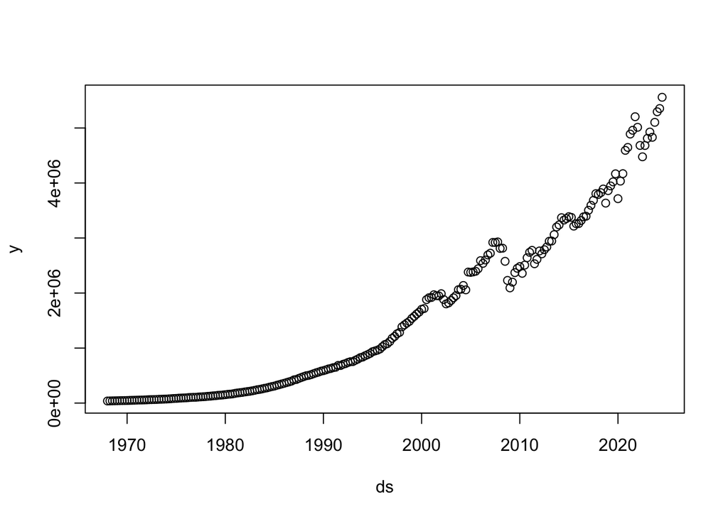

```r
# Firstly we load the data. The original xlsx file from the United States Census
# Bureau contained unfriendly formatting and to make the process easier I
# changed the way the period column was named. This made it easier to set up the
# dataframe.

Pensions_data <- read_excel("data/Pensions data cleaned.xlsx")

# Next I manipulated the Period column of the Pensions data to format it as
# quarters in a year

Pensions_data$ds <- as.yearqtr(Pensions_data$Period, format = "%Y Q%q")

# Then I set up the dataframe. ds represents the quarter and the year and y
# represents money in the public pension fund (specifically in Cash and Security
# Holdings).

pensions.df <- data.frame(ds = Pensions_data$ds, y = Pensions_data$Value)

# The data for 2024 Q4 onwards was unavailable which can cause errors when
# forecasting. Because of this I deleted the last 5 rows from the data frame.
# There are still a good amount of observations so this does not cause a major
# impact on results.

n<-dim(pensions.df)[1]
pensions.df<-pensions.df[1:(n-5),]

# Now we fit the time series model using Prophet. This will help us predict future
# values. The data derived did not offer seasonal adjustment therefore we continue
# with seasonality turned off for the model. This just means that we are not
# assuming that there are periodic patterns at some fixed interval.

ModelWithNoSeasonality = prophet::prophet(pensions.df)

# We then create future dates for forecasting. We are calculating 8 periods
# ahead so we will forecast for 8 future quarters.

FutureQuarters = prophet::make_future_dataframe(ModelWithNoSeasonality, periods=8)

# We can now use the predict function to predict values using the model for 8 future
# quarters

prediction = predict(ModelWithNoSeasonality, FutureQuarters)

# We can plot this as a line graph to see the overall pattern of this time series.

plot(pensions.df)
```

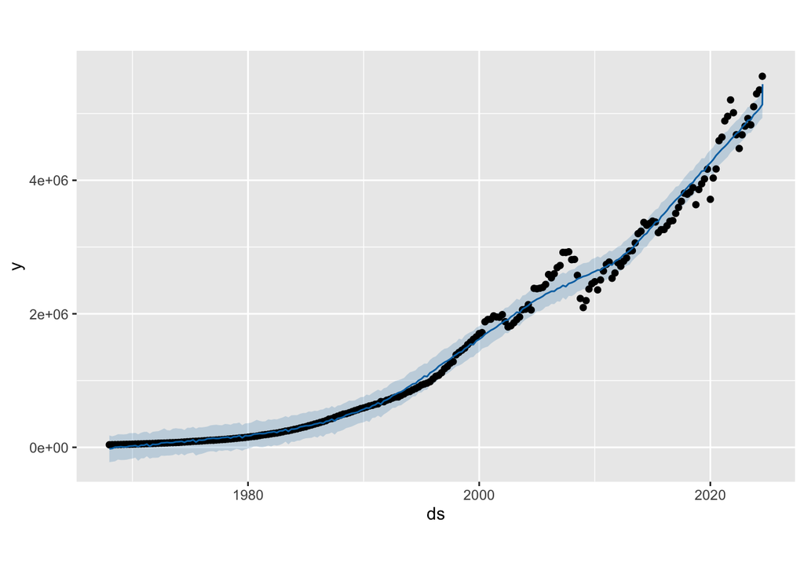

```r
plot(ModelWithNoSeasonality,prediction)
```

```r
# For comparison I plotted the time series data on its own without the fitted trend
# line provided by the Prophet model. The first and second graph are essentially
# the same. The black dots in the second graph are the recorded observations which
# come from the US pensions data. The blue line represents the trend line and the
# blue highlighted area around that line is the confidence interval.
```

## 1.3 Interpretting initial results

In general there is a strong growth trend in the graph. It exhibits signs of exponential growth. This suggests that the amount of money in public pensions funds has grown since 1968. We can confirm this by running a linear regression.

```r
model <- lm(y ~ ds, data = pensions.df)
mosaic::msummary(model)
```

```
##               Estimate Std. Error t value Pr(>|t|)
## (Intercept) -175749403    3777890  -46.52   <2e-16 ***
## ds               88850       1892   46.95   <2e-16 ***
##
## Residual standard error: 467100 on 225 degrees of freedom
## Multiple R-squared:  0.9074, Adjusted R-squared:  0.907
## F-statistic:  2204 on 1 and 225 DF,  p-value: < 2.2e-16
```

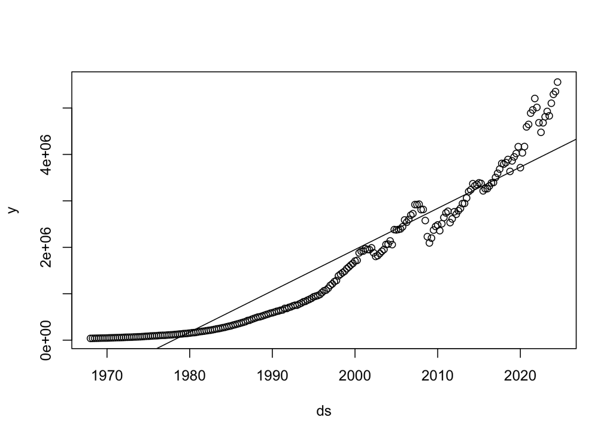

```r
plot(pensions.df)
abline(lm(y ~ ds, data = pensions.df))
```

The line does not fit the trend of the observations. We can try see if a log model may fit this data better.

```r
# The values column was not registering as numeric which meant I could not take logs
# of it. I first set the column to be numeric and then took logs of y.

pensions.df$y <- as.numeric(pensions.df$y)
pensions.df$log_y <- log(pensions.df$y)

# I can now fit the log linear regression model.

log_model <- lm(log_y ~ ds, data = pensions.df)
mosaic::msummary(log_model)
```

```
##               Estimate Std. Error t value Pr(>|t|)
## (Intercept) -164.48721    2.61531  -62.89   <2e-16 ***
## ds             0.08917    0.00131   68.07   <2e-16 ***
##
## Residual standard error: 0.3234 on 225 degrees of freedom
## Multiple R-squared:  0.9537, Adjusted R-squared:  0.9535
## F-statistic:  4633 on 1 and 225 DF,  p-value: < 2.2e-16
```

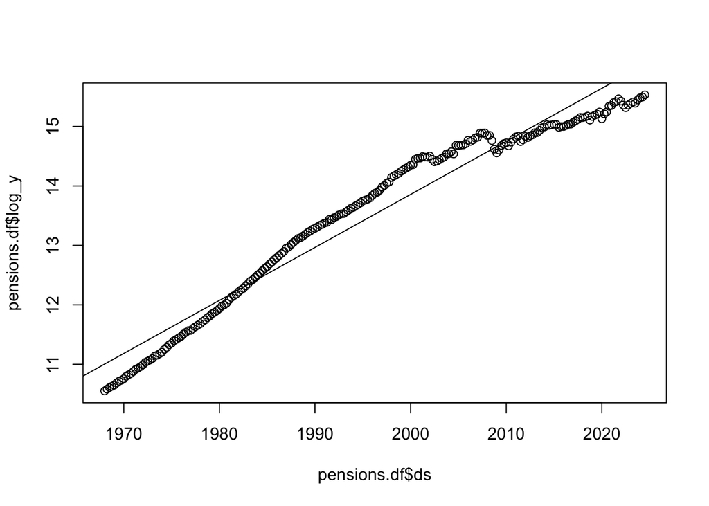

```r
plot(pensions.df$ds, pensions.df$log_y)
abline(log_model)
```

So overall, there is a positive exponential growth trend of the pension funds between 1968 and 2024.

## 1.4 Historical events

Looking back on our original Prophet time series plot, most of the observations fit the trend line which means the Prophet model fit well. After the year 2000 the observations start fluctuating a lot more than they were before. This results in observations outside the trend lines confidence interval. There is a peak and fall between 2008 and 2010 and we can explore this further by looking at potential political and economical events that may have caused this e.g: The Financial Crisis of 2008. We can also look at other historical events such as the COVID-19 pandemic and the early 2000s recession.

To try explain the observations outside the trendline after 2000 and 2008 we can annotate our Prophet graph for historical events to see if our assumptions are correct.

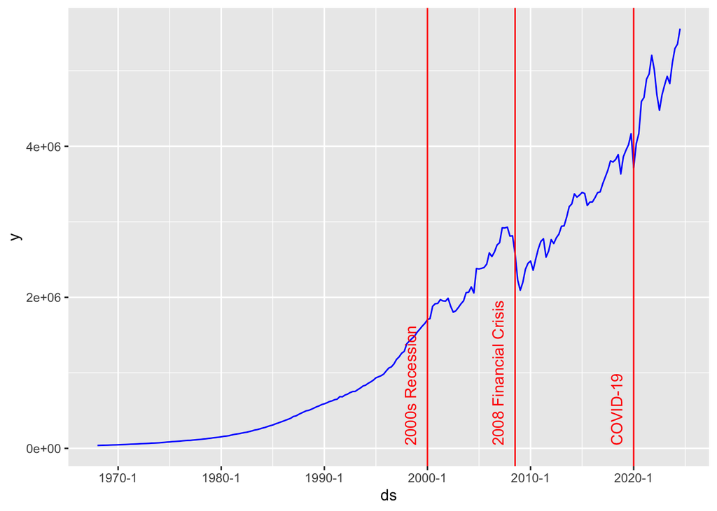

```r
# Firstly we put all the historical events we want to analyse in a dataframe and
# give them the appropriate labels.

events <- data.frame(ds = as.yearqtr(c("2008 Q3", "2020 Q1", "2000 Q1")), label = c("2008 Financial Crisis", "COVID-19", "2000s Recession"))

# We can now plot the original time series graph and annotate it with the events.
# We use geom_line to plot the observations from our time series in a blue line.
# We use geom_vline to create vertical lines at the event dates we previously created
# a dataframe for.
# Geom_text adds labels to the historical events and we can use functions to adjust
# where the label is.

ggplot(pensions.df, aes(x = ds, y = y)) +
geom_line(color = "blue") +
geom_vline(data = events, aes(xintercept = ds), color = "red") +
geom_text(data = events, aes(x = ds, y = min(pensions.df$y), label = label),
vjust = -1, hjust = 0, angle = 90, color = "red")
```

From this plot we can see that the historical events do have some impact on the value of pension funds.

**2000s Recession**

This was caused by a combination of the Dot Com Bubble collapse and also the September 11th attacks. As this data is from the US Census Bureau we should focus on events that affected the US. In the graph we can see that pension funds grow very quickly and then growth stagnates for a while before dipping down. The growth being not as exponential could be due to the side effects of the two events mentioned earlier. This is because these events cause stock prices to decrease.

**2008 Financial Crisis**

There is a very strong decrease in the amount of money the pension fund holds after this event. This financial crisis occurred due to the housing market in the US collapsing.This affected the economy severely and took a while to recover from. The US was largely impacted by this which would explain the decrease in their pension funds.

**COVID-19**

This recent pandemic caused many businesses to close down and saw an increase in redundancies. In the graph we do see a dip around this event but there is a very strong recovery. This may be because the US government had taken precautions to ensure another recession (like the one in 2008) did not happen again.

Overall, we can definitely explain the fluctuations in the graph using these historical events.

## 1.5 Quarterly Seasonality

As our data is in quarters it may be interesting to see if there is any seasonality.

```r
# First we convert the value column of our pensions data into a time series object
# as this makes it easier to conduct the seasonality analysis.

pensions_data.ts <- ts(pensions.df$y, start = c(1968, 1), frequency = 4)

# Now we create labels for each quarter.

SeasonalLabels = factor(cycle(pensions_data.ts),labels=c("Quarter 1", "Quarter 2", "Quarter 3", "Quarter 4"))

# We know from our earlier analysis that a log regression model works the best.
# We can now plot the regression model and view the summary.

logpensions_data.ts = log(pensions_data.ts)
qrtrmodel = lm(logpensions_data.ts~0+SeasonalLabels, na.action=NULL)
mosaic::msummary(qrtrmodel)
```

```
##                         Estimate Std. Error t value Pr(>|t|)
## SeasonalLabelsQuarter 1  13.4991     0.1999   67.53   <2e-16 ***
## SeasonalLabelsQuarter 2  13.5230     0.1999   67.65   <2e-16 ***
## SeasonalLabelsQuarter 3  13.5399     0.1999   67.74   <2e-16 ***
## SeasonalLabelsQuarter 4  13.5303     0.2017   67.09   <2e-16 ***
##
## Residual standard error: 1.509 on 223 degrees of freedom
## Multiple R-squared:  0.9879, Adjusted R-squared:  0.9877
## F-statistic:  4557 on 4 and 223 DF,  p-value: < 2.2e-16
```

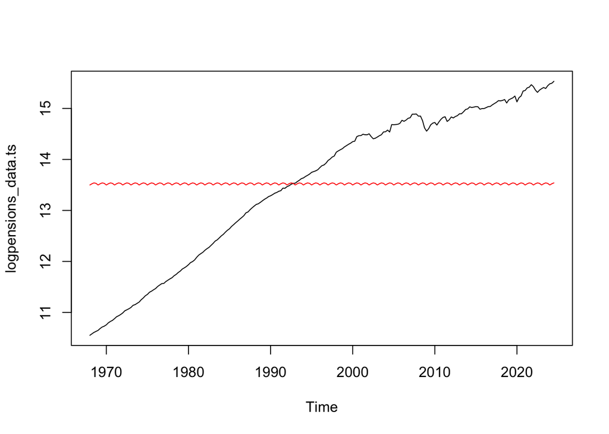

```r
# The estimate for each quarter is quite similar which is expected. Q1 has the
# lowest mean and Q3 has the highest.

# We now plot the time series and the fitted values.

plot(logpensions_data.ts, type="l")
lines(fitted(qrtrmodel), col="red")
```

```r
# The black line shows us the pensions data that we have previously analysed.
# The red line oscillates between the quarters, which suggests there may be a small
# amount of seasonality.

# In order to get a better fit we need to add the trend.
qrtrtrendmodel = lm(log(pensions_data.ts)~0+time(pensions_data.ts)+SeasonalLabels, na.action=NULL)
mosaic::msummary(qrtrtrendmodel)
```

```
##                           Estimate Std. Error t value Pr(>|t|)
## time(pensions_data.ts)   8.917e-02  1.319e-03   67.61   <2e-16 ***
## SeasonalLabelsQuarter 1 -1.645e+02  2.633e+00  -62.48   <2e-16 ***
## SeasonalLabelsQuarter 2 -1.645e+02  2.633e+00  -62.47   <2e-16 ***
## SeasonalLabelsQuarter 3 -1.645e+02  2.633e+00  -62.47   <2e-16 ***
## SeasonalLabelsQuarter 4 -1.645e+02  2.633e+00  -62.47   <2e-16 ***
##
## Residual standard error: 0.3255 on 222 degrees of freedom
## Multiple R-squared:  0.9994, Adjusted R-squared:  0.9994
## F-statistic: 7.928e+04 on 5 and 222 DF,  p-value: < 2.2e-16
```

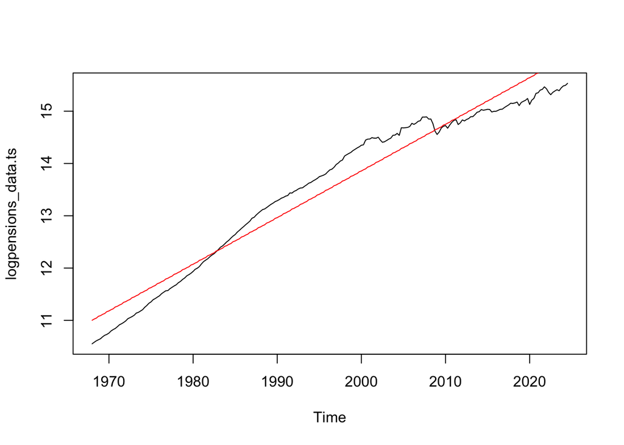

```r
# Now we plot the new regression model.

plot(logpensions_data.ts, type="l")
lines(fitted(qrtrtrendmodel), col="red")
```

```r
# The red line follows the time series much better now and the oscillations are not as
# large as in our previous model. This suggests that the quarters don't have a lot of seasonality.
# The red line does not fit the trend perfectly which means there is something
# missing from the model.
```

Overall, pensions are quite stable so they shouldn’t be largely impacted by the changing quarters. Pension funds are affected by other factors such as economical crises.

# Section 2: Conclusions

In conclusion the amount of money in public pensions funds (specifically Cash and Security Holdings) in the US is growing exponentially and is forecasted to follow this pattern. It does not exhibit any strong seasonality which makes sense as it is a pension fund and should not be volatile. It can however, be affected by major financial events like the 2008 Financial Crisis however it appears that it is becoming more resistant to these events. This can be seen by the quick recovery from the COVID-19 crisis. Stakeholders can feel secure knowing that the pension funds are healthy and are performing well.